# Government Spending on Kids

```r
skimr::skim(kids_raw)
```

```
-- Data Summary ------------------------
                           Values
Name                       kids_raw
Number of rows             1020
Number of columns          25
_______________________
Column type frequency:
  character                1
  numeric                  24
________________________
Group variables            None

-- Variable type: character ---------------------------------------------------------------------------------------
# A tibble: 1 x 8
  skim_variable n_missing complete_rate   min   max empty n_unique whitespace
* <chr>             <int>         <dbl> <int> <int> <int>    <int>      <int>
1 state                 0             1     4    20     0       51          0

-- Variable type: numeric -----------------------------------------------------------------------------------------
# A tibble: 24 x 11
   skim_variable   n_missing complete_rate     mean          sd      p0      p25      p50      p75      p100 hist
 * <chr>               <int>         <dbl>    <dbl>       <dbl>   <dbl>    <dbl>    <dbl>    <dbl>     <dbl> <chr>
 1 year                    0          1       2006.        5.77   1997     2002.    2006.    2011.     2016  ▇▇▇▇▇
 2 pk12ed                  0          1    8277168. 10339527.   524949  2089982. 4823694. 9566585. 68892072  ▇▁▁▁▁
 3 highered                0          1    1844714.  2819488.    48148   488998. 1172824  1995418. 26706188  ▇▁▁▁▁
 4 edsubs                  0          1     395316.   528064.        0    79190.  213552.  521764.  5182384  ▇▁▁▁▁
 5 edservs                 0          1     259827.   277927.   -60139    81884.  180536   304848.  1911349  ▇▂▁▁▁
 6 pell                    0          1     360749.   533565.     7575.   72739.  180325.  441496.  4201604. ▇▁▁▁▁
 7 head_start_priv         0          1      89217.   102713.     3688.   23723.   58628.  106994.   685086. ▇▁▁▁▁
 8 tan_fbasic              0          1     201993.   528022.   -21820.   33736.   73053.  139879.  5036461. ▇▁▁▁▁
 9 othercashserv           0          1    1632073.  2389788.    52541.  405020.  807091. 1945595. 20692808  ▇▁▁▁▁
10 snap                    0          1     371494.   540341.     8146.   74238.  188455.  452264.  4202442. ▇▁▁▁▁
11 socsec                  0          1     336020.   345228.    20815.   91609.  239193.  426949.  1929949. ▇▂▁▁▁
12 fed_ssi                 0          1     135203.   163463.     4294.   27468.   80257.  176235.  1103508. ▇▁▁▁▁
13 fed_eitc                0          1     957867.  1248675.    37444   199590.  563364. 1153704   7748313  ▇▁▁▁▁
14 ctc                     0          1     484028.   558118.        0   111527   335731   627560.  3703393  ▇▂▁▁▁
15 add_cc                  0          1     211396.   503946.        0        0        0   256392.  4143470  ▇▁▁▁▁
16 state_eitc              0          1      42355.   125078.        0        0        0    31187.  1153717. ▇▁▁▁▁
17 unemp                   0          1     949419.  1597004.    12041   152258.  372224  1014535  19104112  ▇▁▁▁▁
18 wcomp                   0          1     207431.   463416.        0      950    23386.  175396.  3219177  ▇▁▁▁▁
19 medicaid_chip          51          0.95 1891241.  2701273.    48350.  447782. 1045259. 2217231. 21920496  ▇▁▁▁▁
20 pubhealth               0          1    1352189.  1968681.    47226   319116.  698844  1601376  19978300  ▇▁▁▁▁
21 other_health           51          0.95 6126892.  8214045.   224504. 1435684. 3820732. 7569350. 83666088  ▇▁▁▁▁
22 hcd                     0          1     672218.   975029.     6525   141244.  310238   787552.  7438719  ▇▁▁▁▁
23 lib                     0          1     166920.   200205.        0    37090.  100436.  214544.  1359466  ▇▁▁▁▁
24 parkrec                 0          1     488296.   653217.    18203   126543.  290636.  570265   5072765  ▇▁▁▁▁
```

The data is very long because they include several measures of the same variables. I widened each one to make it easier to understand them. Here is the raw data point data, skimmed. There are many variables, none of which are listed on the data dictionary on the Github site; you have to go to the package source. (Technically, this data comes from Urban Institute, repackaged by Joshua Rosenberg in his `tidykids` package.) The full codebook can be found [here](https://jrosen48.github.io/tidykids/articles/tidykids-codebook.html). To put it mildly, the data is dense.

- `state` refers to the US, including DC
- `year` Year
- `pk12ed` Public spending on elementary and secondary education by state and year, in $1,000s
- `highered` Public spending on higher education by state and year, in $1,000s
- `edsubs` Public spending on education subsidies, including tuition and scholarships, by state and year, in $1,000s
- `edservs` Public spending on education special services by state and year, in $1,000s
- `pell` Public spending on Pell Grants by state and year, in $1,000s
- `head_start_priv` Federal spending on Head Start awarded to private grantees by state and year, in $1,000s
- `tan_fbasic` Public spending on TANF cash assistance payments by state and year, in $1,000s
- `othercashserv` Public spending on other cash assistance payments and social services by state and year, in $1,000s
- `snap` Public spending on SNAP benefit payments that go to children by state and year, in $1,000s
- `socsec` Public spending on Social Security payments that go to children by state and year, in $1,000s
- `fed_ssi` Federal spending on SSI payments that go to children by state and year, in $1,000s
- `fed_eitc` Federal spending on EITC, including refundable and non-refundable portions, by state and year, in $1,000s
- `ctc` Public spending on the Child Tax Credit, including refundable and non-refundable portions, by state and year, in $1,000s
- `add_cc` Public spending on the Additional Child Tax credit, including only refundable portion, by state and year, in $1,000s
- `state_eitc` Total state spending on EITC by state and year, in $1,000s
- `unemp` Public spending on Unemployment Compensation benefit payments by state and year, in $1,000s
- `wcomp` Public spending on Workers Compensation benefit payments by state and year, in $1,000s
- `medicaid_chip` Public spending on Medicaid (for children and youth <21) and CHIP by state and year, in $1,000s. This variable has a very long description; use caution.
- `pubhealth` Public spending on public health efforts by state and year, in $1,000s
- `other_health` Public spending on health vendor payments and public hospitals, excluding Medicaid, by state and year, in $1,000s
- `hcd` Public spending on housing and community development by state and year, in $1,000s
- `lib` Public spending on libraries by state and year, in $1,000s
- `parkrec` Public spending on parks and recreation by state and year, in $1,000s

Further important definitions:

- **TANF** Temporary Assistance for Needy Families
- **SNAP** Supplemental Nutrition Assistance Program
- **EITC** Earned Income Tax Credit

```
Ignoring unknown aesthetics: width
```

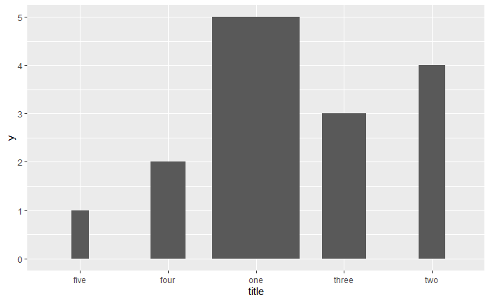

```r
df %>%
  ggplot() +
  geom_col(aes(x = title, y = y, width = x))
```

Well, I had hoped that this would be a cinch, but it seems I will have to define the rectangles myself and use `geom_rect()`. This shouldn’t be too hard, but it’s not great. Let me try with the example dataset above. I need to generate the x max/min and y max/min.

- `ymin` is always zero.
- `ymax` is simply the y value
- `xmin` and `xmax` need processing. First, I need center positions of each bar; second, I need to generate the extremities of the bars. This needs to be done so that there is a constant amount of space between each bar. I’ll start with bars that touch and work inwards from there.

`xcenter` can be defined with the `cumsum` function. Unless I’m mistaken, you can take the average of the cumulative sum and the lagged cumulative sum to generate a center point; but then, with a cumulative sum you can probably outright generate the extremities.

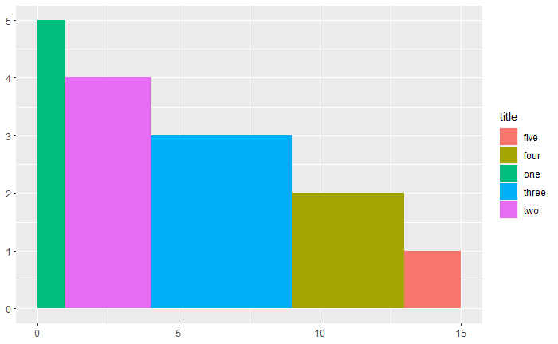

I’ll introduce space by shifting the bars over by a fixed amount. This way, the bars retain their constant width. To shift the bars over by a constant amount, I need to add progressively more to each boundary point.

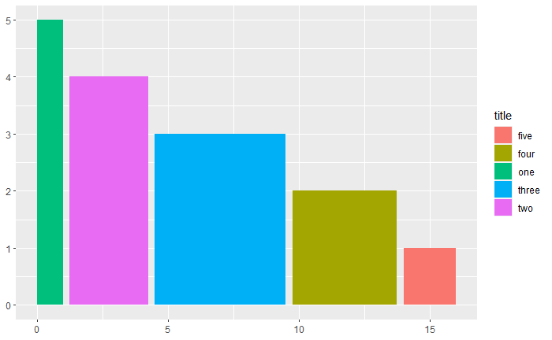

```r
df <- tibble(
  x = c(1, 3, 5, 4, 2),
  y = c(5, 4, 3, 2, 1),
  title = c('one','two','three','four','five')
) %>%
  mutate(
    ymin = 0,
    ymax = y,
    xmax = cumsum(x),
    xmin = lag(xmax, default = 0),
    xminplus = xmin + 0.25*(row_number() - 1),
    xmaxplus = xmax + 0.25*(row_number() - 1)
  )

df %>%
  ggplot() +
  geom_rect(aes(xmin = xminplus, xmax = xmaxplus, ymin = 0, ymax = ymax, fill = title))
```

That looks nice. I’m going to have problems with the x-axis no matter what, though, because the reader will have to do arithmetic to find the width of the bar. I have to be creative, instead. On the [mekko graphics](https://www.mekkographics.com/why-use-a-marimekko-chart/) website, they write the width of the bar at the top of the bar. That would look like this:

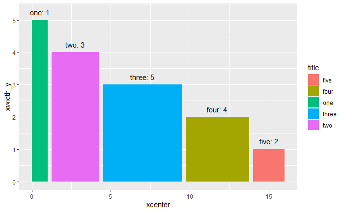

That will have to do. For a theme, I’d like to use something simple and slightly technical looking. Let’s do it with some real data. I need to (a) choose a variable and (b) merge in population data. Alternatively, I could add to the complexity by including an array of variables. I just realized I can derive the number of children.

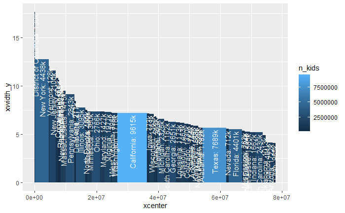

This might look better if I rotate the axes, so the text is read normally and the bars are going to the right. That means doing another long graphic, but I’m more or less okay with that.

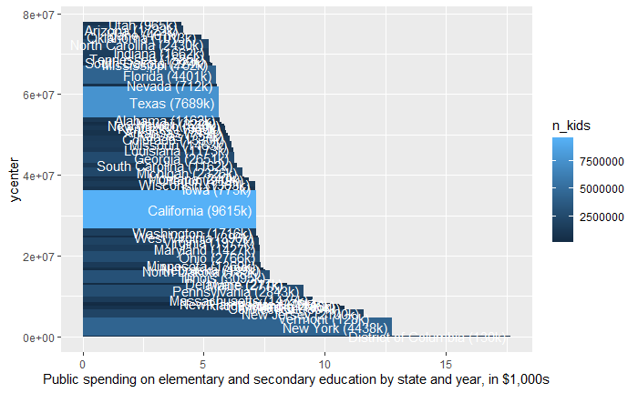

I think this is plenty for an interesting graphic. I can figure out the colors of the bars and the theme in the R file.

I’ve lost interest in the verticality of this. It seems universal to use a long x-axis instead, so that’s what I’m going to do.